# Generalized linear models: logistic regression

Author

Maciej Beręsewicz

# 1 Packages

**R**

```r
install.packages("marginaleffects")
install.packages("modelsummary")
install.packages("performance")
install.packages("pROC")
install.packages("car")
install.packages("broom")
```

```r
library(marginaleffects)
library(modelsummary)
library(performance)
library(pROC)
library(broom)
```

**Python**

```bash
!pip install statsmodels scikit-learn
```

```python
import numpy as np
import pandas as pd
import statsmodels.api as sm
import statsmodels.formula.api as smf
from sklearn.metrics import roc_auc_score, roc_curve
```

**Julia**

```julia
using Pkg
Pkg.add(["GLM", "CSV", "DataFrames", "CategoricalArrays", "Statistics", "StatsBase", "Effects"])
```

```julia
using GLM
using CSV
using DataFrames
using CategoricalArrays
using Statistics
using StatsBase
```

# 2 Data

The Polish Job Vacancy Survey (JVS): one row per firm. We model whether a firm posts at least one vacancy:
$$\text{has\_vacancy}_i = \mathbf{1}\{\text{vacancies}_i > 0\}, \qquad Y_i \in \{0, 1\}.$$

**R**

```r
df <- read.csv("data/polish-jvs.csv",
               colClasses = c("character", "factor", rep("character", 4), "numeric"))
df$size        <- factor(df$size,   levels = c("Large", "Medium", "Small"))
df$public      <- factor(df$public)
df$nace        <- factor(df$nace)
df$has_vacancy <- as.integer(df$vacancies > 0)
head(df)
```

| id | woj | public | size | nace | nace_division | vacancies | has_vacancy |
| --- | --- | --- | --- | --- | --- | --- | --- |
| 27350 | 14 | 1 | Large | O | 84 | 2 | 1 |
| 26705 | 14 | 1 | Large | O | 84 | 1 | 1 |
| 257456 | 24 | 1 | Large | O | 84 | 2 | 1 |
| 183657 | 16 | 1 | Medium | O | 84 | 0 | 0 |
| 200042 | 18 | 1 | Medium | O | 84 | 0 | 0 |
| 26050 | 14 | 1 | Large | R | 91 | 4 | 1 |

```r
c(n         = nrow(df),
  prop_yes  = mean(df$has_vacancy),
  prop_pub  = mean(df$public == "1"))
```

```
           n     prop_yes     prop_pub
5.748000e+04 1.205463e-01 3.523660e-01
```

**Python**

```python
df = pd.read_csv("data/polish-jvs.csv",
                 dtype={"id": np.int64, "woj": str, "public": str,
                        "size": str, "nace_division": str, "nace": str})
df["size"]        = pd.Categorical(df["size"], categories = ["Large", "Medium", "Small"])
df["has_vacancy"] = (df["vacancies"] > 0).astype(int)
df.head()
```

```
       id woj public    size nace nace_division  vacancies  has_vacancy
0   27350  14      1   Large    O            84          2            1
1   26705  14      1   Large    O            84          1            1
2  257456  24      1   Large    O            84          2            1
3  183657  16      1  Medium    O            84          0            0
4  200042  18      1  Medium    O            84          0            0
```

```python
{"n":        len(df),
 "prop_yes": df["has_vacancy"].mean(),
 "prop_pub": (df["public"] == "1").mean()}
```

```
{'n': 57480, 'prop_yes': 0.12054627696590119, 'prop_pub': 0.352366040361865}
```

**Julia**

```julia
df = CSV.read("data/polish-jvs.csv", DataFrame,
              types = Dict(:id => String, :woj => String, :public => String,
                           :size => String, :nace_division => String, :nace => String));
df.size        = categorical(df.size, levels = ["Large", "Medium", "Small"]);
df.public      = categorical(df.public);
df.nace        = categorical(df.nace);
df.has_vacancy = ifelse.(df.vacancies .> 0, 1, 0);
first(df, 5)
```

```
5×8 DataFrame
 Row │ id      woj     public  size    nace  nace_division  vacancies  has_vac ⋯
     │ String  String  Cat…    Cat…    Cat…  String         Int64      Int64   ⋯
─────┼──────────────────────────────────────────────────────────────────────────
   1 │ 27350   14      1       Large   O     84                     2          ⋯
   2 │ 26705   14      1       Large   O     84                     1
   3 │ 257456  24      1       Large   O     84                     2
   4 │ 183657  16      1       Medium  O     84                     0
   5 │ 200042  18      1       Medium  O     84                     0          ⋯
                                                                1 column omitted
```

```julia
(n        = nrow(df),
 prop_yes = mean(df.has_vacancy),
 prop_pub = mean(df.public .== "1"))
```

```
(n = 57480, prop_yes = 0.12054627696590119, prop_pub = 0.352366040361865)
```

About 12% of firms post at least one vacancy.

# 3 Why not LPM?

The **linear probability model** (LPM) fits $P(Y_i = 1 \mid \mathbf{x}_i) = \beta_0 + \mathbf{x}_i^\top\boldsymbol{\beta}$ by OLS. Three issues:

1. fitted probabilities can fall outside $[0, 1]$;
2. residual variance is intrinsically heteroskedastic ($\operatorname{Var}(Y\mid X) = \pi(1-\pi)$);
3. the Gaussian likelihood is misspecified, so likelihood-based inference (LR tests, AIC, normal-theory prediction intervals) does not apply.

Point estimates remain consistent for the **linear approximation** to $\pi(\mathbf{x})$; robust (HC) SEs give asymptotically valid Wald CIs. But the constant marginal-effect assumption and out-of-range predictions are not repairable without changing the model.

**R**

```r
lpm <- lm(has_vacancy ~ size + public + nace, data = df)
preds_lpm <- predict(lpm)
c(min      = round(min(preds_lpm), 4),
  max      = round(max(preds_lpm), 4),
  n_below0 = sum(preds_lpm < 0),
  n_above1 = sum(preds_lpm > 1))
```

```
      min       max  n_below0  n_above1
  -0.0328    0.2997 2353.0000    0.0000
```

**Python**

```python
lpm = smf.ols("has_vacancy ~ C(size) + C(public) + C(nace)", data = df).fit()
preds_lpm = lpm.predict(df)
{"min":      round(preds_lpm.min(), 4),
 "max":      round(preds_lpm.max(), 4),
 "n_below0": int((preds_lpm < 0).sum()),
 "n_above1": int((preds_lpm > 1).sum())}
```

```
{'min': -0.0328, 'max': 0.2997, 'n_below0': 2353, 'n_above1': 0}
```

**Julia**

```julia
lpm = lm(@formula(has_vacancy ~ size + public + nace), df)
```

```
StatsModels.TableRegressionModel{LinearModel{GLM.LmResp{Vector{Float64}}, GLM.DensePredChol{Float64, CholeskyPivoted{Float64, Matrix{Float64}, Vector{Int64}}}}, Matrix{Float64}}

has_vacancy ~ 1 + size + public + nace

Coefficients:
─────────────────────────────────────────────────────────────────────────────────
                    Coef.  Std. Error       t  Pr(>|t|)    Lower 95%    Upper 95%
─────────────────────────────────────────────────────────────────────────────────
(Intercept)    0.112004    0.00783275   14.30    <1e-45   0.096652     0.127356
size: Medium  -0.0801241   0.0032458   -24.69    <1e-99  -0.0864859   -0.0737624
size: Small   -0.120752    0.00375066  -32.19    <1e-99  -0.128103    -0.1134
public: 1      0.0168025   0.00450162    3.73    0.0002   0.00797929   0.0256257
nace: B        0.0135013   0.0140218     0.96    0.3356  -0.0139815    0.040984
nace: C        0.117594    0.00850298   13.83    <1e-42   0.100928     0.13426
nace: D        0.0426196   0.0129586     3.29    0.0010   0.0172207    0.0680185
nace: E        0.0274429   0.00976494    2.81    0.0050   0.00830358   0.0465823
nace: F        0.0786495   0.00937263    8.39    <1e-16   0.0602791    0.0970199
nace: G        0.0468914   0.00873487    5.37    <1e-07   0.029771     0.0640118
nace: H        0.0889872   0.00994267    8.95    <1e-18   0.0694995    0.108475
nace: I        0.0742759   0.0104078     7.14    <1e-12   0.0538766    0.0946752
nace: J        0.0942756   0.0103698     9.09    <1e-18   0.0739507    0.1146
nace: K       -0.00660263  0.0102209    -0.65    0.5183  -0.0266356    0.0134303
nace: L        0.0569566   0.00974598    5.84    <1e-08   0.0378544    0.0760587
nace: M        0.0651818   0.00979031    6.66    <1e-10   0.0459927    0.0843708
nace: N        0.0367587   0.010262      3.58    0.0003   0.0166451    0.0568723
nace: O        0.170869    0.0096542    17.70    <1e-69   0.151947     0.189791
nace: P       -0.024072    0.00830784   -2.90    0.0038  -0.0403554   -0.00778861
nace: Q        0.060742    0.00893981    6.79    <1e-10   0.04322      0.0782641
nace: R        0.0376247   0.00982651    3.83    0.0001   0.0183647    0.0568847
nace: S        0.072986    0.0132775     5.50    <1e-07   0.0469621    0.0990099
─────────────────────────────────────────────────────────────────────────────────
```

```julia
preds_lpm = predict(lpm)
```

```
57480-element Vector{Float64}:
  0.29967584822457316
  0.29967584822457316
  0.29967584822457316
  0.21955170828750836
  0.21955170828750836
  0.1664314326670415
  0.1664314326670415
  0.1664314326670415
  0.08630729272997671
  0.08630729272997671
  ⋮
  0.024610568732618365
  0.10473470866968314
  0.08630729272997671
 -0.00874744797703371
  0.024610568732618365
  0.08630729272997671
  0.04538136600833378
  0.04538136600833378
  0.10884647835573391
```

```julia
(min      = round(minimum(preds_lpm), digits = 4),
 max      = round(maximum(preds_lpm), digits = 4),
 n_below0 = sum(preds_lpm .< 0),
 n_above1 = sum(preds_lpm .> 1))
```

```
(min = -0.0328, max = 0.2997, n_below0 = 2353, n_above1 = 0)
```

LPM produces fitted probabilities outside $[0,1]$ for sub-groups with very low base rates.

# 4 Odds, log-odds, and odds ratios

For a binary response with $\pi = \Pr(Y = 1)$:
$$\text{odds} = \frac{\pi}{1-\pi}, \qquad \operatorname{logit}(\pi) = \log\frac{\pi}{1-\pi}.$$

For two groups with success probabilities $\pi_1, \pi_2$, the **odds ratio** is
$$\theta \;=\; \frac{\pi_1/(1-\pi_1)}{\pi_2/(1-\pi_2)}, \qquad \log \theta \;=\; \operatorname{logit}(\pi_1) - \operatorname{logit}(\pi_2).$$

Compute it from the 2×2 cross-tabulation `public × has_vacancy`:

**R**

```r
tab <- table(public = df$public, has_vacancy = df$has_vacancy)
tab
```

```
      has_vacancy
public     0     1
     0 32912  4314
     1 17639  2615
```

```r
odds_pub  <- tab["1", "1"] / tab["1", "0"]
odds_priv <- tab["0", "1"] / tab["0", "0"]
c(odds_public  = round(odds_pub,  4),
  odds_private = round(odds_priv, 4),
  OR           = round(odds_pub / odds_priv, 4),
  log_OR       = round(log(odds_pub / odds_priv), 4))
```

```
 odds_public odds_private           OR       log_OR
      0.1483       0.1311       1.1310       0.1231
```

**Python**

```python
tab = pd.crosstab(df["public"], df["has_vacancy"])
tab
```

```
has_vacancy      0     1
public
0            32912  4314
1            17639  2615
```

```python
odds_pub  = tab.loc["1", 1] / tab.loc["1", 0]
odds_priv = tab.loc["0", 1] / tab.loc["0", 0]
{"odds_public":  round(odds_pub,  4),
 "odds_private": round(odds_priv, 4),
 "OR":           round(odds_pub / odds_priv, 4),
 "log_OR":       round(np.log(odds_pub / odds_priv), 4)}
```

```
{'odds_public': 0.1483, 'odds_private': 0.1311, 'OR': 1.131, 'log_OR': 0.1231}
```

**Julia**

```julia
tab = combine(groupby(df, [:public, :has_vacancy]), nrow => :n)
```

```
4×3 DataFrame
 Row │ public  has_vacancy  n
     │ Cat…    Int64        Int64
─────┼────────────────────────────
   1 │ 0                 0  32912
   2 │ 0                 1   4314
   3 │ 1                 0  17639
   4 │ 1                 1   2615
```

```julia
unstack(tab, :public, :has_vacancy, :n)
```

```
2×3 DataFrame
 Row │ public  0       1
     │ Cat…    Int64?  Int64?
─────┼────────────────────────
   1 │ 0        32912    4314
   2 │ 1        17639    2615
```

```julia
n11 = sum((df.public .== "1") .& (df.has_vacancy .== 1));
n10 = sum((df.public .== "1") .& (df.has_vacancy .== 0));
n01 = sum((df.public .== "0") .& (df.has_vacancy .== 1));
n00 = sum((df.public .== "0") .& (df.has_vacancy .== 0));
odds_pub  = n11 / n10;
odds_priv = n01 / n00;
(odds_public  = round(odds_pub,  digits = 4),
 odds_private = round(odds_priv, digits = 4),
 OR           = round(odds_pub / odds_priv, digits = 4),
 log_OR       = round(log(odds_pub / odds_priv), digits = 4))
```

```
(odds_public = 0.1483, odds_private = 0.1311, OR = 1.131, log_OR = 0.1231)
```

The OR is about $1.13$: the odds of having a vacancy are roughly $13\%$ higher for public firms than for private ones. The log-OR ($\approx 0.12$) is exactly what a logistic regression on `public` recovers as $\hat{\beta}_1$.

# 5 Logistic regression: fit and interpret

Logistic regression specifies
$$\operatorname{logit}(\pi_i) = \beta_0 + \mathbf{x}_i^\top\boldsymbol{\beta}, \qquad
\pi_i = \frac{\exp(\beta_0 + \mathbf{x}_i^\top\boldsymbol{\beta})}{1 + \exp(\beta_0 + \mathbf{x}_i^\top\boldsymbol{\beta})}.$$

**R**

```r
m1 <- glm(has_vacancy ~ public, data = df, family = binomial(link = "logit"))
summary(m1)
```

```
Call:
glm(formula = has_vacancy ~ public, family = binomial(link = "logit"),
    data = df)

Coefficients:
            Estimate Std. Error  z value Pr(>|z|)
(Intercept) -2.03197    0.01619 -125.492  < 2e-16 ***
public1      0.12312    0.02648    4.649 3.33e-06 ***
---
Signif. codes:  0 '***' 0.001 '**' 0.01 '*' 0.05 '.' 0.1 ' ' 1

(Dispersion parameter for binomial family taken to be 1)

    Null deviance: 42307  on 57479  degrees of freedom
Residual deviance: 42285  on 57478  degrees of freedom
AIC: 42289

Number of Fisher Scoring iterations: 4
```

```r
round(exp(coef(m1)), 4)
```

```
(Intercept)     public1
     0.1311      1.1310
```

The exponentiated coefficient on `public1` matches the OR computed from the 2×2 table.

```r
m_full <- glm(has_vacancy ~ public + size + nace, data = df,
              family = binomial(link = "logit"))
summary(m_full)
```

```
Call:
glm(formula = has_vacancy ~ public + size + nace, family = binomial(link = "logit"),
    data = df)

Coefficients:
            Estimate Std. Error z value Pr(>|z|)
(Intercept) -2.59659    0.11867 -21.880  < 2e-16 ***
public1      0.30889    0.04831   6.393 1.62e-10 ***
sizeMedium  -0.75403    0.03398 -22.189  < 2e-16 ***
sizeSmall   -1.38640    0.04697 -29.517  < 2e-16 ***
naceB        0.24733    0.21622   1.144 0.252668
naceC        1.43090    0.12151  11.776  < 2e-16 ***
naceD        0.76564    0.16502   4.640 3.49e-06 ***
naceE        0.53758    0.13864   3.878 0.000106 ***
naceF        1.20840    0.12837   9.413  < 2e-16 ***
naceG        0.91364    0.12522   7.296 2.96e-13 ***
naceH        1.24983    0.13008   9.608  < 2e-16 ***
naceI        1.16894    0.13630   8.576  < 2e-16 ***
naceJ        1.37829    0.13532  10.185  < 2e-16 ***
naceK        0.20644    0.14866   1.389 0.164931
naceL        0.97069    0.13502   7.189 6.53e-13 ***
naceM        1.03759    0.13159   7.885 3.14e-15 ***
naceN        0.77784    0.14008   5.553 2.81e-08 ***
naceO        1.58327    0.12382  12.787  < 2e-16 ***
naceP       -0.09844    0.12360  -0.796 0.425790
naceQ        0.91758    0.12456   7.367 1.75e-13 ***
naceR        0.66918    0.13490   4.961 7.02e-07 ***
naceS        1.21256    0.16809   7.214 5.44e-13 ***
---
Signif. codes:  0 '***' 0.001 '**' 0.01 '*' 0.05 '.' 0.1 ' ' 1

(Dispersion parameter for binomial family taken to be 1)

    Null deviance: 42307  on 57479  degrees of freedom
Residual deviance: 39042  on 57458  degrees of freedom
AIC: 39086

Number of Fisher Scoring iterations: 5
```

```r
modelsummary(list(`logit (public)` = m1,
                  `logit (full)`   = m_full),
             exponentiate = TRUE,
             statistic    = "({std.error})",
             gof_omit     = "F|RMSE")
```

|  | logit (public) | logit (full) |
| --- | --- | --- |
| (Intercept) | 0.131 | 0.075 |
|  | (0.002) | (0.009) |
| public1 | 1.131 | 1.362 |
|  | (0.030) | (0.066) |
| sizeMedium |  | 0.470 |
|  |  | (0.016) |
| sizeSmall |  | 0.250 |
|  |  | (0.012) |
| naceB |  | 1.281 |
|  |  | (0.277) |
| naceC |  | 4.182 |
|  |  | (0.508) |
| naceD |  | 2.150 |
|  |  | (0.355) |
| naceE |  | 1.712 |
|  |  | (0.237) |
| naceF |  | 3.348 |
|  |  | (0.430) |
| naceG |  | 2.493 |
|  |  | (0.312) |
| naceH |  | 3.490 |
|  |  | (0.454) |
| naceI |  | 3.219 |
|  |  | (0.439) |
| naceJ |  | 3.968 |
|  |  | (0.537) |
| naceK |  | 1.229 |
|  |  | (0.183) |
| naceL |  | 2.640 |
|  |  | (0.356) |
| naceM |  | 2.822 |
|  |  | (0.371) |
| naceN |  | 2.177 |
|  |  | (0.305) |
| naceO |  | 4.871 |
|  |  | (0.603) |
| naceP |  | 0.906 |
|  |  | (0.112) |
| naceQ |  | 2.503 |
|  |  | (0.312) |
| naceR |  | 1.953 |
|  |  | (0.263) |
| naceS |  | 3.362 |
|  |  | (0.565) |
| Num.Obs. | 57480 | 57480 |
| AIC | 42289.2 | 39085.9 |
| BIC | 42307.1 | 39283.0 |
| Log.Lik. | -21142.607 | -19520.937 |

```r
car::Anova(m_full, type = 2) |> broom::tidy()
```

| term | statistic | df | p.value |
| --- | --- | --- | --- |
| public | 40.79875 | 1 | 0 |
| size | 1262.93059 | 2 | 0 |
| nace | 1431.50608 | 18 | 0 |

**Python**

```python
m1 = smf.glm("has_vacancy ~ C(public)", data = df,
             family = sm.families.Binomial()).fit()
print(m1.summary())
```

```
                 Generalized Linear Model Regression Results
==============================================================================
Dep. Variable:            has_vacancy   No. Observations:                57480
Model:                            GLM   Df Residuals:                    57478
Model Family:                Binomial   Df Model:                            1
Link Function:                  Logit   Scale:                          1.0000
Method:                          IRLS   Log-Likelihood:                -21143.
Date:                Sat, 02 May 2026   Deviance:                       42285.
Time:                        23:36:28   Pearson chi2:                 5.75e+04
No. Iterations:                     5   Pseudo R-squ. (CS):          0.0003730
Covariance Type:            nonrobust
==================================================================================
                     coef    std err          z      P>|z|      [0.025      0.975]
----------------------------------------------------------------------------------
Intercept         -2.0320      0.016   -125.491      0.000      -2.064      -2.000
C(public)[T.1]     0.1231      0.026      4.649      0.000       0.071       0.175
==================================================================================
```

```python
np.exp(m1.params).round(4)
```

```
Intercept         0.1311
C(public)[T.1]    1.1310
dtype: float64
```

```python
m_full = smf.glm("has_vacancy ~ C(public) + C(size) + C(nace)", data = df,
                 family = sm.families.Binomial()).fit()
print(m_full.summary())
```

```
                 Generalized Linear Model Regression Results
==============================================================================
Dep. Variable:            has_vacancy   No. Observations:                57480
Model:                            GLM   Df Residuals:                    57458
Model Family:                Binomial   Df Model:                           21
Link Function:                  Logit   Scale:                          1.0000
Method:                          IRLS   Log-Likelihood:                -19521.
Date:                Sat, 02 May 2026   Deviance:                       39042.
Time:                        23:36:28   Pearson chi2:                 5.81e+04
No. Iterations:                     6   Pseudo R-squ. (CS):            0.05522
Covariance Type:            nonrobust
=====================================================================================
                        coef    std err          z      P>|z|      [0.025      0.975]
-------------------------------------------------------------------------------------
Intercept            -2.5966      0.119    -21.871      0.000      -2.829      -2.364
C(public)[T.1]        0.3089      0.048      6.393      0.000       0.214       0.404
C(size)[T.Medium]    -0.7540      0.034    -22.188      0.000      -0.821      -0.687
C(size)[T.Small]     -1.3864      0.047    -29.513      0.000      -1.478      -1.294
C(nace)[T.B]          0.2473      0.216      1.144      0.253      -0.177       0.671
C(nace)[T.C]          1.4309      0.122     11.771      0.000       1.193       1.669
C(nace)[T.D]          0.7656      0.165      4.639      0.000       0.442       1.089
C(nace)[T.E]          0.5376      0.139      3.876      0.000       0.266       0.809
C(nace)[T.F]          1.2084      0.128      9.410      0.000       0.957       1.460
C(nace)[T.G]          0.9136      0.125      7.294      0.000       0.668       1.159
C(nace)[T.H]          1.2498      0.130      9.605      0.000       0.995       1.505
C(nace)[T.I]          1.1689      0.136      8.574      0.000       0.902       1.436
C(nace)[T.J]          1.3783      0.135     10.182      0.000       1.113       1.644
C(nace)[T.K]          0.2064      0.149      1.388      0.165      -0.085       0.498
C(nace)[T.L]          0.9707      0.135      7.187      0.000       0.706       1.235
C(nace)[T.M]          1.0376      0.132      7.882      0.000       0.780       1.296
C(nace)[T.N]          0.7778      0.140      5.551      0.000       0.503       1.052
C(nace)[T.O]          1.5833      0.124     12.782      0.000       1.341       1.826
C(nace)[T.P]         -0.0984      0.124     -0.796      0.426      -0.341       0.144
C(nace)[T.Q]          0.9176      0.125      7.364      0.000       0.673       1.162
C(nace)[T.R]          0.6692      0.135      4.959      0.000       0.405       0.934
C(nace)[T.S]          1.2126      0.168      7.212      0.000       0.883       1.542
=====================================================================================
```

**Julia**

```julia
m1 = glm(@formula(has_vacancy ~ public), df, Bernoulli(), LogitLink())
```

```
StatsModels.TableRegressionModel{GeneralizedLinearModel{GLM.GlmResp{Vector{Float64}, Bernoulli{Float64}, LogitLink}, GLM.DensePredChol{Float64, CholeskyPivoted{Float64, Matrix{Float64}, Vector{Int64}}}}, Matrix{Float64}}

has_vacancy ~ 1 + public

Coefficients:
────────────────────────────────────────────────────────────────────────────
                 Coef.  Std. Error        z  Pr(>|z|)   Lower 95%  Upper 95%
────────────────────────────────────────────────────────────────────────────
(Intercept)  -2.03197    0.016192   -125.49    <1e-99  -2.06371    -2.00024
public: 1     0.123124   0.0264817     4.65    <1e-05   0.0712203   0.175027
────────────────────────────────────────────────────────────────────────────
```

```julia
exp.(coef(m1))
```

```
2-element Vector{Float64}:
 0.1310768109517658
 1.1310241190978758
```

```julia
m_full = glm(@formula(has_vacancy ~ public + size + nace), df,
             Bernoulli(), LogitLink())
```

```
StatsModels.TableRegressionModel{GeneralizedLinearModel{GLM.GlmResp{Vector{Float64}, Bernoulli{Float64}, LogitLink}, GLM.DensePredChol{Float64, CholeskyPivoted{Float64, Matrix{Float64}, Vector{Int64}}}}, Matrix{Float64}}

has_vacancy ~ 1 + public + size + nace

Coefficients:
─────────────────────────────────────────────────────────────────────────────
                   Coef.  Std. Error       z  Pr(>|z|)   Lower 95%  Upper 95%
─────────────────────────────────────────────────────────────────────────────
(Intercept)   -2.59659     0.118674   -21.88    <1e-99  -2.82919    -2.36399
public: 1      0.308886    0.0483147    6.39    <1e-09   0.21419     0.403581
size: Medium  -0.754028    0.0339827  -22.19    <1e-99  -0.820633   -0.687423
size: Small   -1.3864      0.0469701  -29.52    <1e-99  -1.47846    -1.29434
nace: B        0.247331    0.216218     1.14    0.2527  -0.176449    0.671111
nace: C        1.4309      0.121512    11.78    <1e-31   1.19274     1.66906
nace: D        0.765645    0.165017     4.64    <1e-05   0.442217    1.08907
nace: E        0.537583    0.13864      3.88    0.0001   0.265854    0.809312
nace: F        1.2084      0.128375     9.41    <1e-20   0.956791    1.46001
nace: G        0.913636    0.125219     7.30    <1e-12   0.668212    1.15906
nace: H        1.24983     0.130084     9.61    <1e-21   0.994876    1.50479
nace: I        1.16894     0.136297     8.58    <1e-17   0.901799    1.43607
nace: J        1.37829     0.13532     10.19    <1e-23   1.11307     1.64352
nace: K        0.20644     0.14866      1.39    0.1649  -0.0849275   0.497809
nace: L        0.970686    0.135024     7.19    <1e-12   0.706044    1.23533
nace: M        1.03759     0.131588     7.89    <1e-14   0.779679    1.2955
nace: N        0.777842    0.140079     5.55    <1e-07   0.503291    1.05239
nace: O        1.58327     0.12382     12.79    <1e-36   1.34059     1.82596
nace: P       -0.0984383   0.123602    -0.80    0.4258  -0.340693    0.143816
nace: Q        0.91758     0.124555     7.37    <1e-12   0.673456    1.1617
nace: R        0.669184    0.134896     4.96    <1e-06   0.404793    0.933575
nace: S        1.21256     0.168086     7.21    <1e-12   0.883116    1.542
─────────────────────────────────────────────────────────────────────────────
```

**Interpretation.** A unit change in $X_j$ (others fixed) shifts the log-odds by $\beta_j$:
$$\beta_j = \operatorname{logit}(\pi_+) - \operatorname{logit}(\pi_-) = \log \theta_j.$$
So $\hat{\beta}_j$ is the log odds ratio, and $\exp(\hat{\beta}_j)$ is the odds ratio.

# 6 Other links: probit and cloglog

The link $g$ in $g(\pi_i) = \beta_0 + \mathbf{x}_i^\top\boldsymbol{\beta}$ does not have to be the logit:

- **logit**: $g(\pi) = \log\frac{\pi}{1-\pi}$.
- **probit**: $g(\pi) = \Phi^{-1}(\pi)$.
- **cloglog**: $g(\pi) = \log(-\log(1-\pi))$ — asymmetric, used when the positive (or negative) outcome is rare.

**R**

```r
m_logit   <- glm(has_vacancy ~ public + size + nace, data = df,
                 family = binomial(link = "logit"))
m_probit  <- glm(has_vacancy ~ public + size + nace, data = df,
                 family = binomial(link = "probit"))
m_cloglog <- glm(has_vacancy ~ public + size + nace, data = df,
                 family = binomial(link = "cloglog"))

# Coefficients side-by-side (link scale)
modelsummary(list(logit   = m_logit,
                  probit  = m_probit,
                  cloglog = m_cloglog),
             statistic = "({std.error})",
             gof_omit  = "F|RMSE")
```

|  | logit | probit | cloglog |
| --- | --- | --- | --- |
| (Intercept) | -2.597 | -1.429 | -2.652 |
|  | (0.119) | (0.055) | (0.115) |
| public1 | 0.309 | 0.148 | 0.289 |
|  | (0.048) | (0.025) | (0.044) |
| sizeMedium | -0.754 | -0.396 | -0.701 |
|  | (0.034) | (0.018) | (0.032) |
| sizeSmall | -1.386 | -0.709 | -1.304 |
|  | (0.047) | (0.023) | (0.045) |
| naceB | 0.247 | 0.111 | 0.236 |
|  | (0.216) | (0.100) | (0.210) |
| naceC | 1.431 | 0.710 | 1.350 |
|  | (0.122) | (0.057) | (0.117) |
| naceD | 0.766 | 0.349 | 0.741 |
|  | (0.165) | (0.081) | (0.157) |
| naceE | 0.538 | 0.248 | 0.520 |
|  | (0.139) | (0.066) | (0.134) |
| naceF | 1.208 | 0.590 | 1.144 |
|  | (0.128) | (0.061) | (0.123) |
| naceG | 0.914 | 0.420 | 0.881 |
|  | (0.125) | (0.059) | (0.121) |
| naceH | 1.250 | 0.610 | 1.185 |
|  | (0.130) | (0.062) | (0.124) |
| naceI | 1.169 | 0.557 | 1.118 |
|  | (0.136) | (0.066) | (0.130) |
| naceJ | 1.378 | 0.666 | 1.309 |
|  | (0.135) | (0.065) | (0.129) |
| naceK | 0.206 | 0.063 | 0.212 |
|  | (0.149) | (0.070) | (0.144) |
| naceL | 0.971 | 0.448 | 0.935 |
|  | (0.135) | (0.064) | (0.130) |
| naceM | 1.038 | 0.494 | 0.990 |
|  | (0.132) | (0.063) | (0.126) |
| naceN | 0.778 | 0.354 | 0.752 |
|  | (0.140) | (0.067) | (0.135) |
| naceO | 1.583 | 0.826 | 1.460 |
|  | (0.124) | (0.059) | (0.118) |
| naceP | -0.098 | -0.075 | -0.079 |
|  | (0.124) | (0.057) | (0.120) |
| naceQ | 0.918 | 0.433 | 0.884 |
|  | (0.125) | (0.059) | (0.120) |
| naceR | 0.669 | 0.312 | 0.644 |
|  | (0.135) | (0.064) | (0.130) |
| naceS | 1.213 | 0.578 | 1.157 |
|  | (0.168) | (0.082) | (0.161) |
| Num.Obs. | 57480 | 57480 | 57480 |
| AIC | 39085.9 | 39103.4 | 39084.4 |
| BIC | 39283.0 | 39300.5 | 39281.5 |
| Log.Lik. | -19520.937 | -19529.722 | -19520.186 |

```r
round(coef(m_logit) / coef(m_probit), 3)
```

```
(Intercept)     public1  sizeMedium   sizeSmall       naceB       naceC
      1.816       2.080       1.903       1.956       2.222       2.015
      naceD       naceE       naceF       naceG       naceH       naceI
      2.192       2.168       2.049       2.173       2.047       2.099
      naceJ       naceK       naceL       naceM       naceN       naceO
      2.070       3.296       2.166       2.098       2.194       1.916
      naceP       naceQ       naceR       naceS
      1.310       2.118       2.143       2.099
```

**Python**

```python
m_logit  = smf.glm("has_vacancy ~ C(public) + C(size) + C(nace)", data = df,
                   family = sm.families.Binomial(sm.families.links.Logit())).fit()
m_probit = smf.glm("has_vacancy ~ C(public) + C(size) + C(nace)", data = df,
                   family = sm.families.Binomial(sm.families.links.Probit())).fit()
ratio = (m_logit.params / m_probit.params).round(3)
print(ratio)
```

```
Intercept            1.816
C(public)[T.1]       2.080
C(size)[T.Medium]    1.903
C(size)[T.Small]     1.956
C(nace)[T.B]         2.222
C(nace)[T.C]         2.015
C(nace)[T.D]         2.192
C(nace)[T.E]         2.168
C(nace)[T.F]         2.049
C(nace)[T.G]         2.173
C(nace)[T.H]         2.047
C(nace)[T.I]         2.099
C(nace)[T.J]         2.070
C(nace)[T.K]         3.296
C(nace)[T.L]         2.166
C(nace)[T.M]         2.098
C(nace)[T.N]         2.194
C(nace)[T.O]         1.916
C(nace)[T.P]         1.310
C(nace)[T.Q]         2.118
C(nace)[T.R]         2.143
C(nace)[T.S]         2.099
dtype: float64
```

**Julia**

```julia
m_logit  = glm(@formula(has_vacancy ~ public + size + nace), df,
               Bernoulli(), LogitLink())
```

```
StatsModels.TableRegressionModel{GeneralizedLinearModel{GLM.GlmResp{Vector{Float64}, Bernoulli{Float64}, LogitLink}, GLM.DensePredChol{Float64, CholeskyPivoted{Float64, Matrix{Float64}, Vector{Int64}}}}, Matrix{Float64}}

has_vacancy ~ 1 + public + size + nace

Coefficients:
─────────────────────────────────────────────────────────────────────────────
                   Coef.  Std. Error       z  Pr(>|z|)   Lower 95%  Upper 95%
─────────────────────────────────────────────────────────────────────────────
(Intercept)   -2.59659     0.118674   -21.88    <1e-99  -2.82919    -2.36399
public: 1      0.308886    0.0483147    6.39    <1e-09   0.21419     0.403581
size: Medium  -0.754028    0.0339827  -22.19    <1e-99  -0.820633   -0.687423
size: Small   -1.3864      0.0469701  -29.52    <1e-99  -1.47846    -1.29434
nace: B        0.247331    0.216218     1.14    0.2527  -0.176449    0.671111
nace: C        1.4309      0.121512    11.78    <1e-31   1.19274     1.66906
nace: D        0.765645    0.165017     4.64    <1e-05   0.442217    1.08907
nace: E        0.537583    0.13864      3.88    0.0001   0.265854    0.809312
nace: F        1.2084      0.128375     9.41    <1e-20   0.956791    1.46001
nace: G        0.913636    0.125219     7.30    <1e-12   0.668212    1.15906
nace: H        1.24983     0.130084     9.61    <1e-21   0.994876    1.50479
nace: I        1.16894     0.136297     8.58    <1e-17   0.901799    1.43607
nace: J        1.37829     0.13532     10.19    <1e-23   1.11307     1.64352
nace: K        0.20644     0.14866      1.39    0.1649  -0.0849275   0.497809
nace: L        0.970686    0.135024     7.19    <1e-12   0.706044    1.23533
nace: M        1.03759     0.131588     7.89    <1e-14   0.779679    1.2955
nace: N        0.777842    0.140079     5.55    <1e-07   0.503291    1.05239
nace: O        1.58327     0.12382     12.79    <1e-36   1.34059     1.82596
nace: P       -0.0984383   0.123602    -0.80    0.4258  -0.340693    0.143816
nace: Q        0.91758     0.124555     7.37    <1e-12   0.673456    1.1617
nace: R        0.669184    0.134896     4.96    <1e-06   0.404793    0.933575
nace: S        1.21256     0.168086     7.21    <1e-12   0.883116    1.542
─────────────────────────────────────────────────────────────────────────────
```

```julia
m_probit = glm(@formula(has_vacancy ~ public + size + nace), df,
               Bernoulli(), ProbitLink())
```

```
StatsModels.TableRegressionModel{GeneralizedLinearModel{GLM.GlmResp{Vector{Float64}, Bernoulli{Float64}, ProbitLink}, GLM.DensePredChol{Float64, CholeskyPivoted{Float64, Matrix{Float64}, Vector{Int64}}}}, Matrix{Float64}}

has_vacancy ~ 1 + public + size + nace

Coefficients:
──────────────────────────────────────────────────────────────────────────────
                   Coef.  Std. Error       z  Pr(>|z|)   Lower 95%   Upper 95%
──────────────────────────────────────────────────────────────────────────────
(Intercept)   -1.42945     0.0549287  -26.02    <1e-99  -1.53711    -1.32179
public: 1      0.148484    0.025425     5.84    <1e-08   0.0986519   0.198316
size: Medium  -0.396256    0.0175897  -22.53    <1e-99  -0.430731   -0.36178
size: Small   -0.708699    0.0227818  -31.11    <1e-99  -0.75335    -0.664047
nace: B        0.111296    0.0999058    1.11    0.2653  -0.084516    0.307107
nace: C        0.709986    0.0569466   12.47    <1e-34   0.598372    0.821599
nace: D        0.349345    0.0807633    4.33    <1e-04   0.191052    0.507638
nace: E        0.247935    0.0655208    3.78    0.0002   0.119517    0.376354
nace: F        0.589725    0.0608709    9.69    <1e-21   0.47042     0.70903
nace: G        0.420483    0.0587935    7.15    <1e-12   0.30525     0.535716
nace: H        0.610438    0.062467     9.77    <1e-21   0.488005    0.732871
nace: I        0.557016    0.0655671    8.50    <1e-16   0.428507    0.685525
nace: J        0.665734    0.0652234   10.21    <1e-23   0.537898    0.793569
nace: K        0.0626254   0.0698835    0.90    0.3702  -0.0743438   0.199595
nace: L        0.448049    0.0642457    6.97    <1e-11   0.32213     0.573968
nace: M        0.494497    0.0628977    7.86    <1e-14   0.37122     0.617774
nace: N        0.354465    0.0669001    5.30    <1e-06   0.223343    0.485587
nace: O        0.826435    0.0594091   13.91    <1e-43   0.709995    0.942874
nace: P       -0.0751265   0.0574609   -1.31    0.1911  -0.187748    0.0374949
nace: Q        0.433171    0.0589035    7.35    <1e-12   0.317722    0.54862
nace: R        0.312311    0.0641038    4.87    <1e-05   0.186669    0.437952
nace: S        0.577789    0.0817523    7.07    <1e-11   0.417557    0.738021
──────────────────────────────────────────────────────────────────────────────
```

```julia
round.(coef(m_logit) ./ coef(m_probit), digits = 3)
```

```
22-element Vector{Float64}:
 1.816
 2.08
 1.903
 1.956
 2.222
 2.015
 2.192
 2.168
 2.049
 2.173
 ⋮
 3.296
 2.166
 2.098
 2.194
 1.916
 1.31
 2.118
 2.143
 2.099
```

# 7 Marginal effects

Coefficients live on the link scale. To express effects on the **probability scale**, differentiate $\pi_i = G(\beta_0 + \mathbf{x}_i^\top\boldsymbol{\beta})$:
$$\frac{\partial \pi_i}{\partial x_{ij}} \;=\; g(\hat{\eta}_i)\,\hat{\beta}_j,$$
where $g$ is the inverse-link density. Three flavors:

- **AME** (average marginal effect): average of $g(\hat{\eta}_i)\hat{\beta}_j$ over the sample;
- **MEM** (at the mean): $g(\hat{\beta}_0 + \bar{\mathbf{x}}^\top\hat{\boldsymbol{\beta}})\hat{\beta}_j$;
- **MER** (at representative values): evaluated at user-chosen $\mathbf{x}^\star$.

The AME is the default in `marginaleffects`, `statsmodels`, and Stata’s `margins`.

**R**

```r
avg_slopes(m_full)
```

```
   Term       Contrast Estimate Std. Error       z Pr(>|z|)     S    2.5 %
 nace   B - A           0.01380    0.01270   1.086    0.277   1.9 -0.01110
 nace   C - A           0.13211    0.00792  16.678   <0.001 205.0  0.11659
 nace   D - A           0.05356    0.01246   4.300   <0.001  15.8  0.02915
 nace   E - A           0.03406    0.00839   4.061   <0.001  14.3  0.01762
 nace   F - A           0.10198    0.00916  11.128   <0.001  93.1  0.08402
 nace   G - A           0.06812    0.00766   8.890   <0.001  60.5  0.05310
 nace   H - A           0.10729    0.00974  11.019   <0.001  91.4  0.08821
 nace   I - A           0.09706    0.01068   9.091   <0.001  63.1  0.07613
 nace   J - A           0.12462    0.01150  10.838   <0.001  88.5  0.10209
 nace   K - A           0.01131    0.00805   1.405    0.160   2.6 -0.00446
 nace   L - A           0.07416    0.00958   7.741   <0.001  46.5  0.05538
 nace   M - A           0.08155    0.00925   8.817   <0.001  59.6  0.06342
 nace   N - A           0.05471    0.00945   5.791   <0.001  27.1  0.03619
 nace   O - A           0.15509    0.00954  16.253   <0.001 194.9  0.13639
 nace   P - A          -0.00473    0.00612  -0.772    0.440   1.2 -0.01672
 nace   Q - A           0.06853    0.00768   8.925   <0.001  61.0  0.05348
 nace   R - A           0.04490    0.00846   5.306   <0.001  23.1  0.02831
 nace   S - A           0.10251    0.01657   6.186   <0.001  30.6  0.07003
 public 1 - 0           0.03188    0.00516   6.180   <0.001  30.5  0.02177
 size   Medium - Large -0.07998    0.00332 -24.085   <0.001 423.4 -0.08649
 size   Small - Large  -0.11908    0.00317 -37.570   <0.001   Inf -0.12529
   97.5 %
  0.03870
  0.14764
  0.07798
  0.05049
  0.11995
  0.08314
  0.12637
  0.11798
  0.14716
  0.02709
  0.09293
  0.09967
  0.07322
  0.17379
  0.00727
  0.08358
  0.06148
  0.13499
  0.04199
 -0.07347
 -0.11287

Type: response
```

`marginaleffects` differentiates $\pi$ for each observation, then averages — the right thing to do when the link is non-identity.

```r
slopes(m_full, newdata = "mean")
```

```
   Term       Contrast Estimate Std. Error       z Pr(>|z|)     S    2.5 %
 nace   B - A           0.01777    0.01633   1.088    0.277   1.9 -0.01424
 nace   C - A           0.16828    0.00926  18.173   <0.001 242.7  0.15013
 nace   D - A           0.06877    0.01601   4.294   <0.001  15.8  0.03738
 nace   E - A           0.04379    0.01088   4.026   <0.001  14.1  0.02247
 nace   F - A           0.13034    0.01132  11.513   <0.001  99.5  0.10815
 nace   G - A           0.08735    0.00945   9.245   <0.001  65.2  0.06883
 nace   H - A           0.13704    0.01221  11.222   <0.001  94.7  0.11311
 nace   I - A           0.12411    0.01344   9.234   <0.001  65.1  0.09776
 nace   J - A           0.15888    0.01434  11.082   <0.001  92.4  0.13078
 nace   K - A           0.01457    0.01032   1.412    0.158   2.7 -0.00565
 nace   L - A           0.09503    0.01226   7.750   <0.001  46.6  0.07100
 nace   M - A           0.10443    0.01182   8.838   <0.001  59.8  0.08127
 nace   N - A           0.07023    0.01190   5.900   <0.001  28.0  0.04690
 nace   O - A           0.19697    0.01347  14.624   <0.001 158.5  0.17057
 nace   P - A          -0.00609    0.00788  -0.773    0.439   1.2 -0.02153
 nace   Q - A           0.08787    0.01019   8.624   <0.001  57.1  0.06790
 nace   R - A           0.05768    0.01119   5.153   <0.001  21.9  0.03574
 nace   S - A           0.13100    0.02098   6.244   <0.001  31.1  0.08988
 public 1 - 0           0.02097    0.00301   6.958   <0.001  38.1  0.01506
 size   Medium - Large -0.03247    0.00227 -14.293   <0.001 151.5 -0.03692
 size   Small - Large  -0.04666    0.00294 -15.871   <0.001 186.0 -0.05243
   97.5 %
  0.04977
  0.18643
  0.10016
  0.06510
  0.15253
  0.10586
  0.16098
  0.15045
  0.18698
  0.03479
  0.11907
  0.12759
  0.09356
  0.22337
  0.00935
  0.10784
  0.07962
  0.17213
  0.02687
 -0.02802
 -0.04090

Type: response
```

```r
predictions(m_full,
            newdata = datagrid(public = c("0", "1"),
                               size   = "Medium",
                               nace   = "C")) |>
  as.data.frame() |>
  subset(select = c("public", "size", "nace", "estimate", "conf.low", "conf.high"))
```

| public | size | nace | estimate | conf.low | conf.high |
| --- | --- | --- | --- | --- | --- |
| 0 | Medium | C | 0.1278933 | 0.1189754 | 0.1373755 |
| 1 | Medium | C | 0.1664735 | 0.1494295 | 0.1850385 |

**Python**

```python
mfx = m_full.get_margeff(at = "overall", method = "dydx")
print(mfx.summary())
```

```
         GLM Marginal Effects
=====================================
Dep. Variable:            has_vacancy
Method:                          dydx
At:                           overall
=====================================================================================
                       dy/dx    std err          z      P>|z|      [0.025      0.975]
-------------------------------------------------------------------------------------
C(public)[T.1]        0.0308      0.005      6.391      0.000       0.021       0.040
C(size)[T.Medium]    -0.0753      0.003    -22.182      0.000      -0.082      -0.069
C(size)[T.Small]     -0.1384      0.005    -29.321      0.000      -0.148      -0.129
C(nace)[T.B]          0.0247      0.022      1.143      0.253      -0.018       0.067
C(nace)[T.C]          0.1428      0.012     11.759      0.000       0.119       0.167
C(nace)[T.D]          0.0764      0.016      4.637      0.000       0.044       0.109
C(nace)[T.E]          0.0537      0.014      3.875      0.000       0.027       0.081
C(nace)[T.F]          0.1206      0.013      9.400      0.000       0.095       0.146
C(nace)[T.G]          0.0912      0.013      7.287      0.000       0.067       0.116
C(nace)[T.H]          0.1247      0.013      9.596      0.000       0.099       0.150
C(nace)[T.I]          0.1167      0.014      8.566      0.000       0.090       0.143
C(nace)[T.J]          0.1376      0.014     10.171      0.000       0.111       0.164
C(nace)[T.K]          0.0206      0.015      1.388      0.165      -0.008       0.050
C(nace)[T.L]          0.0969      0.013      7.182      0.000       0.070       0.123
C(nace)[T.M]          0.1036      0.013      7.876      0.000       0.078       0.129
C(nace)[T.N]          0.0776      0.014      5.548      0.000       0.050       0.105
C(nace)[T.O]          0.1580      0.012     12.782      0.000       0.134       0.182
C(nace)[T.P]         -0.0098      0.012     -0.796      0.426      -0.034       0.014
C(nace)[T.Q]          0.0916      0.012      7.359      0.000       0.067       0.116
C(nace)[T.R]          0.0668      0.013      4.957      0.000       0.040       0.093
C(nace)[T.S]          0.1210      0.017      7.208      0.000       0.088       0.154
=====================================================================================
```

```python
mfx_mean = m_full.get_margeff(at = "mean", method = "dydx")
print(mfx_mean.summary())
```

```
         GLM Marginal Effects
=====================================
Dep. Variable:            has_vacancy
Method:                          dydx
At:                              mean
=====================================================================================
                       dy/dx    std err          z      P>|z|      [0.025      0.975]
-------------------------------------------------------------------------------------
C(public)[T.1]        0.0274      0.004      6.419      0.000       0.019       0.036
C(size)[T.Medium]    -0.0669      0.003    -22.465      0.000      -0.073      -0.061
C(size)[T.Small]     -0.1230      0.004    -31.471      0.000      -0.131      -0.115
C(nace)[T.B]          0.0219      0.019      1.144      0.253      -0.016       0.060
C(nace)[T.C]          0.1269      0.011     11.920      0.000       0.106       0.148
C(nace)[T.D]          0.0679      0.015      4.653      0.000       0.039       0.097
C(nace)[T.E]          0.0477      0.012      3.886      0.000       0.024       0.072
C(nace)[T.F]          0.1072      0.011      9.507      0.000       0.085       0.129
C(nace)[T.G]          0.0811      0.011      7.351      0.000       0.059       0.103
C(nace)[T.H]          0.1109      0.011      9.698      0.000       0.088       0.133
C(nace)[T.I]          0.1037      0.012      8.649      0.000       0.080       0.127
C(nace)[T.J]          0.1223      0.012     10.296      0.000       0.099       0.146
C(nace)[T.K]          0.0183      0.013      1.389      0.165      -0.008       0.044
C(nace)[T.L]          0.0861      0.012      7.236      0.000       0.063       0.109
C(nace)[T.M]          0.0921      0.012      7.943      0.000       0.069       0.115
C(nace)[T.N]          0.0690      0.012      5.579      0.000       0.045       0.093
C(nace)[T.O]          0.1405      0.011     12.904      0.000       0.119       0.162
C(nace)[T.P]         -0.0087      0.011     -0.796      0.426      -0.030       0.013
C(nace)[T.Q]          0.0814      0.011      7.413      0.000       0.060       0.103
C(nace)[T.R]          0.0594      0.012      4.978      0.000       0.036       0.083
C(nace)[T.S]          0.1076      0.015      7.259      0.000       0.079       0.137
=====================================================================================
```

**Julia**

`Effects.jl` provides predicted probabilities at user-chosen design points; for AME you can differentiate manually:

```julia
pi_hat = predict(m_full)
```

```
57480-element Vector{Float64}:
 0.33083103678272824
 0.33083103678272824
 0.33083103678272824
 0.18870339549218684
 0.18870339549218684
 0.16540933254673668
 0.16540933254673668
 0.16540933254673668
 0.08529025113496504
 0.08529025113496504
 ⋮
 0.04148039686277849
 0.08423566859128537
 0.08529025113496504
 0.01828917436663046
 0.04148039686277849
 0.08529025113496504
 0.042971931990297536
 0.042971931990297536
 0.07228646318426271
```

```julia
g_hat  = pi_hat .* (1 .- pi_hat)         # logistic density g(eta) = pi*(1-pi)
```

```
57480-element Vector{Float64}:
 0.22138186188399334
 0.22138186188399334
 0.22138186188399334
 0.15309442402190615
 0.15309442402190615
 0.13804908525317974
 0.13804908525317974
 0.13804908525317974
 0.07801582419629963
 0.07801582419629963
 ⋮
 0.039759773538884886
 0.07714002072826451
 0.07801582419629963
 0.01795468046761745
 0.039759773538884886
 0.07801582419629963
 0.041125345051318776
 0.041125345051318776
 0.06706113042457294
```

```julia
beta   = coef(m_full)
```

```
22-element Vector{Float64}:
 -2.5965879235111555
  0.30888557874117223
 -0.7540284608532918
 -1.3863995464229961
  0.24733082232933318
  1.4309013540133673
  0.7656447580996596
  0.5375826333701458
  1.2084010766564859
  0.9136359423257049
  ⋮
  0.2064404907737925
  0.9706856909790872
  1.037587436041461
  0.7778417127501839
  1.5832735378214593
 -0.09843825765901955
  0.9175803270815466
  0.6691841638358229
  1.2125583689583423
```

```julia
ame_public = mean(g_hat) * beta[2]
```

```
0.030829514081964163
```

```julia
round(ame_public, digits = 4)
```

```
0.0308
```

# 8 Goodness of fit and discrimination

Fit, discrimination, and calibration can all disagree: a model can have low deviance but poor AUC, or high AUC but bad calibration. Always look at multiple summaries.

**R**

Likelihood-based summaries:

```r
c(deviance     = round(deviance(m_full), 1),
  AIC          = round(AIC(m_full), 1),
  BIC          = round(BIC(m_full), 1),
  null_dev     = round(m_full$null.deviance, 1),
  df_residual  = m_full$df.residual)
```

```
   deviance         AIC         BIC    null_dev df_residual
    39041.9     39085.9     39283.0     42306.7     57458.0
```

McFadden pseudo-$R^2$ and friends via `performance`:

```r
performance::r2_mcfadden(m_full)
```

```
# R2 for Generalized Linear Regression
       R2: 0.077
  adj. R2: 0.077
```

```r
performance::r2_tjur(m_full)
```

```
 Tjur's R2
0.05887541
```

LR test against a reduced model (drop `nace`):

```r
m_red <- glm(has_vacancy ~ public + size, data = df,
             family = binomial(link = "logit"))
anova(m_red, m_full, test = "LRT")
```

| Resid. Df | Resid. Dev | Df | Deviance | Pr(>Chi) |
| --- | --- | --- | --- | --- |
| 57476 | 40473.38 | NA | NA | NA |
| 57458 | 39041.87 | 18 | 1431.506 | 0 |

ROC and AUC:

```r
df$pi_hat <- predict(m_full, type = "response")
roc_obj <- pROC::roc(df$has_vacancy, df$pi_hat, quiet = TRUE)
auc(roc_obj)
```

```
Area under the curve: 0.7054
```

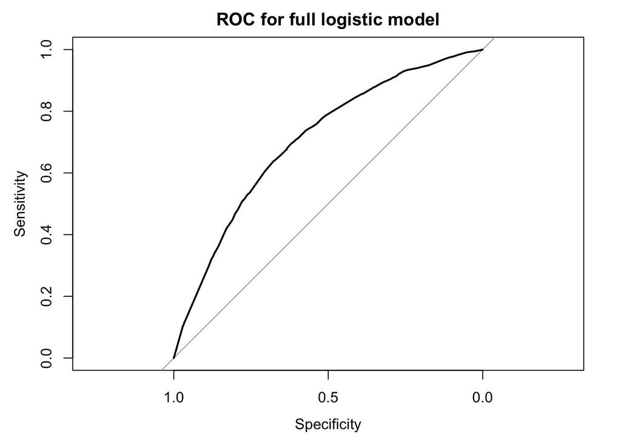

```r
plot(roc_obj, main = "ROC for full logistic model")
```

Calibration plot (deciles of $\hat{\pi}$ vs. observed proportion):

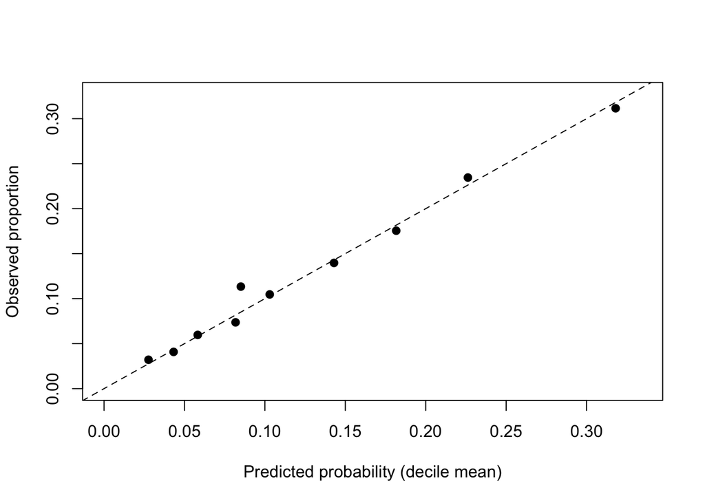

```r
df$bin <- cut(df$pi_hat,
              breaks = quantile(df$pi_hat, probs = seq(0, 1, by = 0.1)),
              include.lowest = TRUE)
calib <- aggregate(cbind(pi_hat, has_vacancy) ~ bin, data = df, FUN = mean)
plot(calib$pi_hat, calib$has_vacancy,
     xlim = c(0, max(calib$pi_hat) * 1.05),
     ylim = c(0, max(calib$has_vacancy) * 1.05),
     xlab = "Predicted probability (decile mean)",
     ylab = "Observed proportion",
     pch  = 19)
abline(0, 1, lty = 2)
```

**Python**

```python
{"deviance":     round(m_full.deviance, 1),
 "AIC":          round(m_full.aic, 1),
 "BIC":          round(m_full.bic_llf, 1),
 "null_dev":     round(m_full.null_deviance, 1),
 "df_residual":  int(m_full.df_resid)}
```

```
{'deviance': 39041.9, 'AIC': 39085.9, 'BIC': 39283.0, 'null_dev': 42306.7, 'df_residual': 57458}
```

```python
m_red = smf.glm("has_vacancy ~ C(public) + C(size)", data = df,
                family = sm.families.Binomial()).fit()
LR = 2 * (m_full.llf - m_red.llf)
df_diff = int(m_red.df_resid - m_full.df_resid)
from scipy import stats
{"LR_stat": round(LR, 2),
 "df":      df_diff,
 "p_value": stats.chi2.sf(LR, df_diff)}
```

```
{'LR_stat': 1431.51, 'df': 18, 'p_value': 2.453945522663766e-293}
```

```python
pi_hat = m_full.predict(df)
auc = roc_auc_score(df["has_vacancy"], pi_hat)
round(auc, 4)
```

```
0.7054
```

**Julia**

```julia
(deviance    = round(deviance(m_full), digits = 1),
 aic         = round(aic(m_full), digits = 1),
 bic         = round(bic(m_full), digits = 1),
 df_residual = dof_residual(m_full))
```

```
(deviance = 39041.9, aic = 39085.9, bic = 39283.0, df_residual = 57459.0)
```

A high AUC means the model **ranks** observations well; calibration tells whether the predicted probabilities are on the right level. They can come apart, so check both.

# 9 Aggregated data

Logistic regression accepts grouped/aggregated counts as a `cbind(successes, failures)` response in R or `freq_weights` / explicit count columns in Python. The point estimates are identical to fitting on individual data.

**R**

```r
agg <- aggregate(cbind(yes = has_vacancy, n = 1) ~ public + size,
                 data = df, FUN = sum)
agg$no <- agg$n - agg$yes
head(agg)
```

| public | size | yes | n | no |
| --- | --- | --- | --- | --- |
| 0 | Large | 2950 | 15873 | 12923 |
| 1 | Large | 1981 | 11968 | 9987 |
| 0 | Medium | 889 | 10647 | 9758 |
| 1 | Medium | 486 | 5836 | 5350 |
| 0 | Small | 475 | 10706 | 10231 |
| 1 | Small | 148 | 2450 | 2302 |

```r
m_agg <- glm(cbind(yes, no) ~ public + size, data = agg,
             family = binomial(link = "logit"))
round(coef(m_agg), 4)
```

```
(Intercept)     public1  sizeMedium   sizeSmall
    -1.5026     -0.0788     -0.8668     -1.4847
```

```r
m_ind <- glm(has_vacancy ~ public + size, data = df,
             family = binomial(link = "logit"))
round(coef(m_ind), 4)
```

```
(Intercept)     public1  sizeMedium   sizeSmall
    -1.5026     -0.0788     -0.8668     -1.4847
```

**Python**

```python
agg = (df.groupby(["public", "size"], observed = True)["has_vacancy"]
         .agg(yes = "sum", n = "size")
         .reset_index())
agg["no"] = agg["n"] - agg["yes"]
agg
```

```
  public    size   yes      n     no
0      0   Large  2950  15873  12923
1      0  Medium   889  10647   9758
2      0   Small   475  10706  10231
3      1   Large  1981  11968   9987
4      1  Medium   486   5836   5350
5      1   Small   148   2450   2302
```

```python
m_agg = smf.glm("yes + no ~ C(public) + C(size)", data = agg,
                family = sm.families.Binomial()).fit()
m_agg.params.round(4)
```

```
Intercept           -1.5026
C(public)[T.1]      -0.0788
C(size)[T.Medium]   -0.8668
C(size)[T.Small]    -1.4847
dtype: float64
```

**Julia**

```julia
agg = combine(groupby(df, [:public, :size]),
              :has_vacancy => sum => :yes,
              nrow => :n);
agg.no = agg.n .- agg.yes;
first(agg, 6)
```

```
6×5 DataFrame
 Row │ public  size    yes    n      no
     │ Cat…    Cat…    Int64  Int64  Int64
─────┼─────────────────────────────────────
   1 │ 0       Large    2950  15873  12923
   2 │ 0       Medium    889  10647   9758
   3 │ 0       Small     475  10706  10231
   4 │ 1       Large    1981  11968   9987
   5 │ 1       Medium    486   5836   5350
   6 │ 1       Small     148   2450   2302
```

The two routes give identical $\hat{\boldsymbol{\beta}}$.

# 10 Exercises

## 10.1 Exercise 1 — link choice

Fit the same `has_vacancy ~ public + size + nace` model with logit, probit, and cloglog links. Compare:

1. fitted probabilities (scatter `logit` vs. `probit`);
2. AICs;
3. ROC AUC.

Does any link clearly dominate?

## 10.2 Exercise 2 — calibration after adding NACE division

Refit the full model adding `nace_division` (the 2-digit code) on top of `nace`. Does AUC improve? Does calibration improve at the high-$\hat{\pi}$ end?

## 10.3 Exercise 3 — separation diagnostic

For each NACE letter, compute the proportion of firms with `has_vacancy = 1`. Are there sectors with $0\%$ or $100\%$ vacancies? In a logistic regression with `nace` as a predictor, what would you expect to happen to the corresponding coefficient and its SE?

# 11 Further reading

- **Theory.** Agresti, A. (2013). *Categorical Data Analysis* (3rd ed.). Wiley. Hosmer, D. W., Lemeshow, S., & Sturdivant, R. X. (2013). *Applied Logistic Regression* (3rd ed.). Wiley.
- **Marginal effects.** Arel-Bundock, V. (2024). *Marginal and Conditional Effects in R*. https://marginaleffects.com/.
- **LPM, robust SEs.** Wooldridge, J. M. (2010). *Econometric Analysis of Cross Section and Panel Data* (2nd ed.). MIT Press, ch. 15.
- **Diagnostics.** `DHARMa` (simulated residuals for binomial GLMs), `pROC`, `performance` (calibration, pseudo-$R^2$), `marginaleffects` (AME, MEM, MER).
- **Calibration.** Steyerberg, E. W. (2019). *Clinical Prediction Models* (2nd ed.). Springer, ch. 15.

# 12 Script files

The code for this document can be found here:

- 10-glm-lr.R
- 10-glm-lr.jl
- 10-glm-lr.py
- 10-glm-lr.sh